# IMD and calls

RS MA NK EK

28/01/2022

## Overview

Since the 1970s the Ministry of Housing, Communities and Local Government and its predecessors have calculated local measures of deprivation in England. The Index of Multiple Deprivation (IMD) is the official measure of relative deprivation in England. The IMD is based on 39 separate indicators, organised across seven distinct domains of deprivation, which combine to produce an overall measure of multiple deprivation experienced by people living in an area. All neighbourhoods (LSOAs) in England are ranked according to their level of deprivation relative to that of other areas. High ranking LSOAs or neighbourhoods can be referred to as the ‘most deprived’ or as being ‘highly deprived’ to aid interpretation. However, there is no definitive threshold above which an area is described as ‘deprived’. The Indices of Deprivation measure deprivation on a relative rather than an absolute scale, so a neighbourhood ranked 100th is more deprived then a neighbourhood ranked 200th, but this does not mean it is twice as deprived. [Ministry of Housing, Communities and Local Government](https://assets.publishing.service.gov.uk/government/uploads/system/uploads/attachment_data/file/835115/IoD2019_Statistical_Release.pdf).

In this report we will categorise areas by dividing them into 10 equal groups (or deciles) according to their deprivation rank.

In Cheshire, there are LSOAs whcih fall into all 10 of the deciles. Areas shaded dark red are in the most deprived 10 per cent (or decile) of neighbourhoods in England while areas dark blue are in the least deprived 10 per cent.

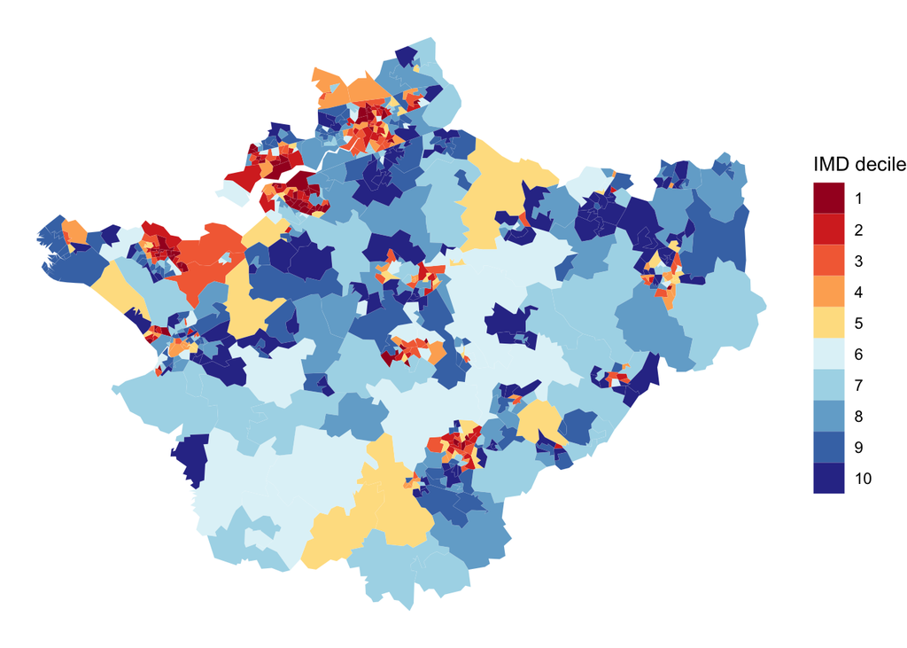

However looking at the number of LSOAs which fall into each decile, we can see there are quite a lot of LSOAs which fall into the less deprived categories:

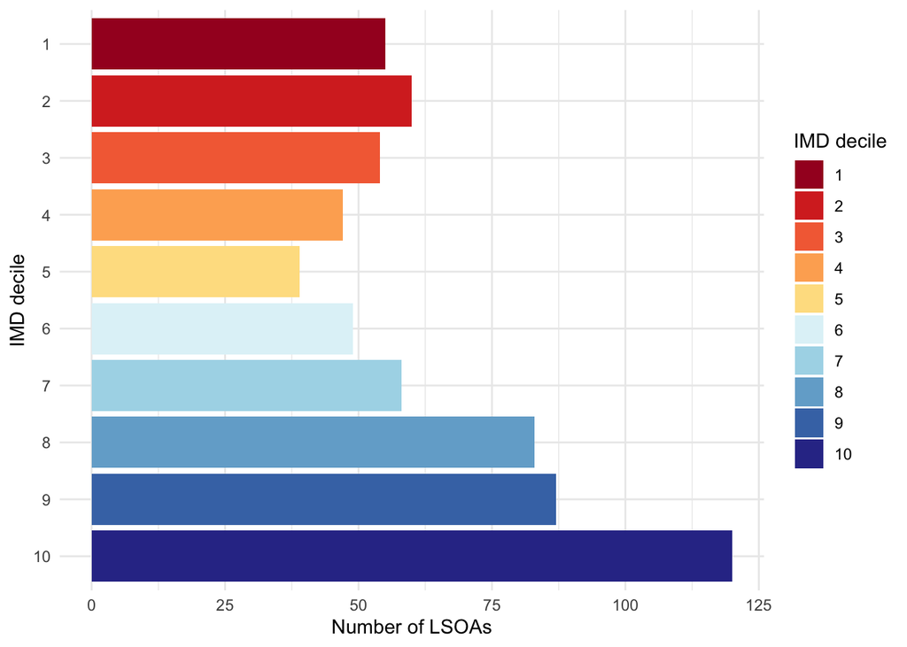

## Volume of calls

Overall we see more calls for service from LSOAs in the more deprived areas than from LSOAs in the less deprived areas.

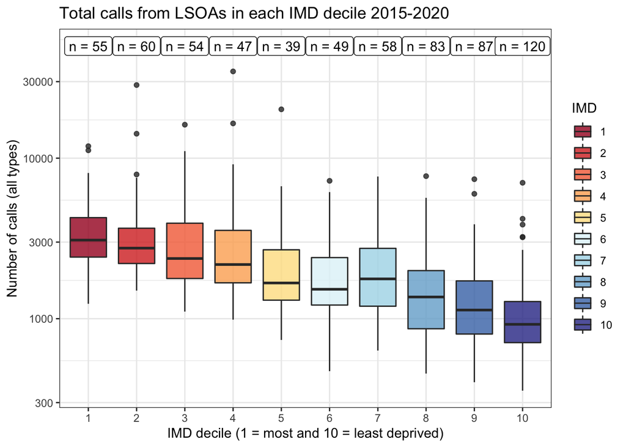

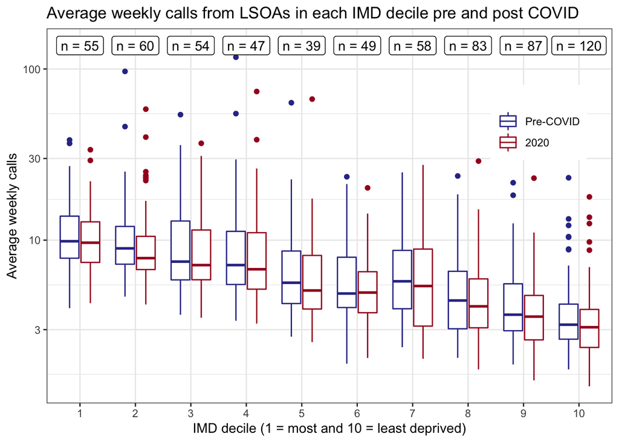

We can see that over time a steady pattern whereby larger proportion of the calls are coming from the areas which score lower on the index (i.e. are more deprived). We consider the proportion of calls coming from each decile of IMD (accounting for the uneven number of LSOAs in each decile):

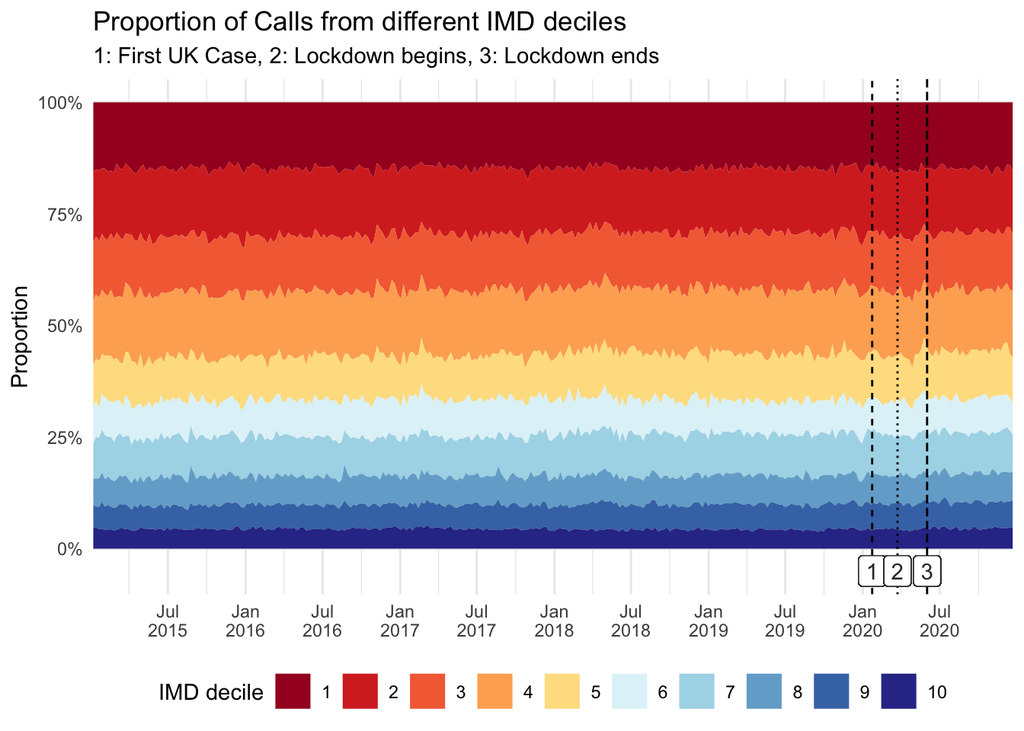

We can zoom into the time period immediately preceding and following the lockdown period, however we see no real shift in where the calls were coming from in terms of the levels of deprivation in these areas.

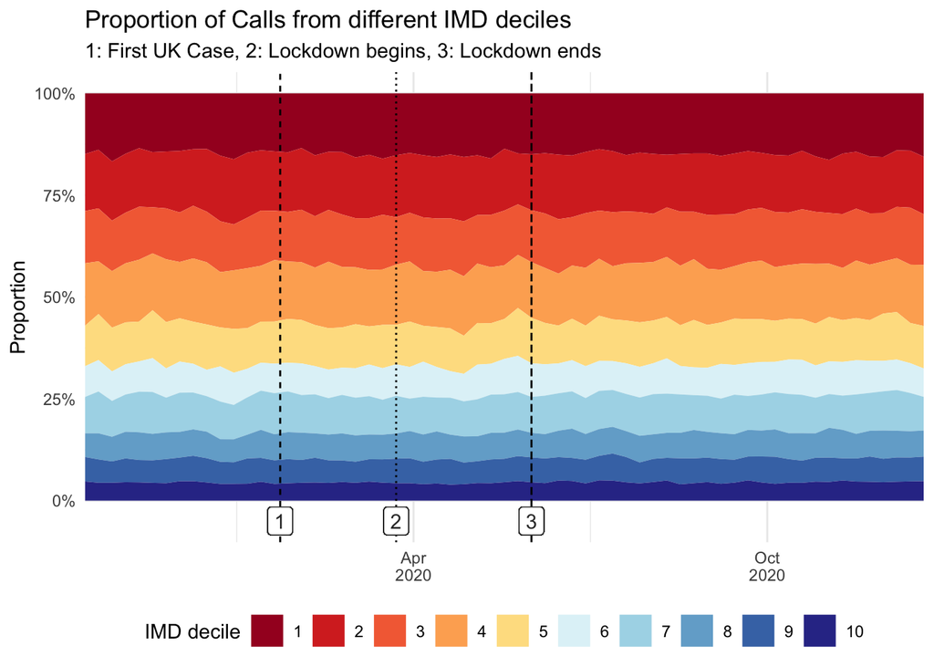